# PSTAT 131 HW 3

Katherine Bayt

2022-04-16

## QUESTION 1

```r
titanic_split <- initial_split(titanic, prop = 0.7,
                               strata = survived)
titanic_train <- training(titanic_split)
titanic_test <- testing(titanic_split)
```

It is a good idea to use stratified sampling because our number of observations are somewhat low for the testing and training data, with 623 observations in the training set and 268 observations in the testing set. Without stratifying on survival, we could end up with a testing group with majority survivors or majority non survivors. Thus, when creating a model to fit this data, the model will not work well when introduced to new data. Therefore, we want to get a distribution of survivors to non that is consistent with the whole data set. Some potential issues within the training set it that there is missing data in ages and cabin for many observations.

## QUESTION 2

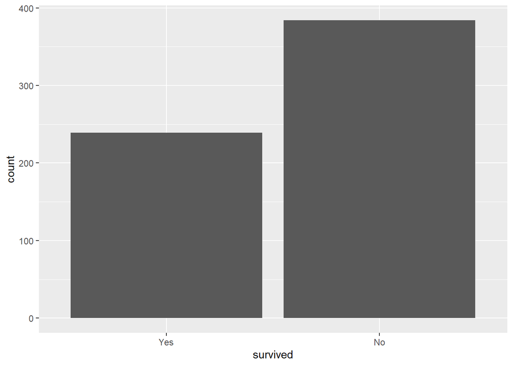

```r
titanic_train %>% ggplot(aes(x = survived)) + geom_bar()
```

Within the training set, there was a larger number of people that died on the titanic than those that survived. This is to be expected because there was only enough lifeboats to save women and children mainly from richer families.

## QUESTION 3

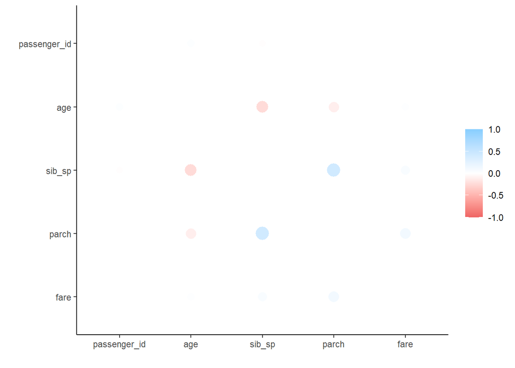

There is a negative correlation of about 0.5 between number of siblings / spouses aboard and age. Intuitively this makes sense because as a person gets older, they will most likely only have their spouse on the boat with them, thus decreasing number of siblings and spouses on board. In comparison, a person of lower age (such as a child) will most likely have some siblings on board. There is a positive correlation of about 0.5 between number of siblings / spouses aboard and number of parents / children aboard. There is a very small negative correlation between number of parents / children aboard and age. There is also a small positive correlation between passenger fare and number of parents / children aboard.

## QUESTION 4

```r
titanic_recipe <- recipe(survived ~ pclass + sex +
                           age + sib_sp + parch + fare,
                         data = titanic_train) %>%
  step_impute_linear(age) %>%
  step_dummy(all_nominal_predictors()) %>%
  step_interact(terms =~starts_with("sex"):fare) %>%
  step_interact(terms=~age:fare)
```

## QUESTION 5

```r
log_reg <- logistic_reg() %>%
  set_engine("glm") %>%
  set_mode("classification")

log_wkflow <- workflow() %>%
  add_model(log_reg) %>%
  add_recipe(titanic_recipe)

log_fit <- fit(log_wkflow, titanic_train)
log_fit
```

```
## == Workflow [trained] ==========================================================
## Preprocessor: Recipe
## Model: logistic_reg()
##
## -- Preprocessor ----------------------------------------------------------------
## 4 Recipe Steps
##
## * step_impute_linear()
## * step_dummy()
## * step_interact()
## * step_interact()
##
## -- Model -----------------------------------------------------------------------
##
## Call:  stats::glm(formula = ..y ~ ., family = stats::binomial, data = data)
##
## Coefficients:
##     (Intercept)              age           sib_sp            parch
##      -4.4764468        0.0547806        0.4042647        0.1411611
##            fare        pclass_X2        pclass_X3         sex_male
##       0.0051493        1.0738502        2.4678528        2.6747289
## sex_male_x_fare       age_x_fare
##       0.0040263       -0.0003088
##
## Degrees of Freedom: 622 Total (i.e. Null);  613 Residual
## Null Deviance:       829.6
## Residual Deviance: 544.4     AIC: 564.4
```

## QUESTION 6

```r
lda_mod <- discrim_linear() %>%
  set_mode("classification") %>%
  set_engine("MASS")

lda_wkflow <- workflow() %>%
  add_model(lda_mod) %>%
  add_recipe(titanic_recipe)

lda_fit <- fit(lda_wkflow, titanic_train)
lda_fit
```

```
## == Workflow [trained] ==========================================================
## Preprocessor: Recipe
## Model: discrim_linear()
##
## -- Preprocessor ----------------------------------------------------------------
## 4 Recipe Steps
##
## * step_impute_linear()
## * step_dummy()
## * step_interact()
## * step_interact()
##
## -- Model -----------------------------------------------------------------------
## Call:
## lda(..y ~ ., data = data)
##
## Prior probabilities of groups:
##       Yes        No
## 0.3836276 0.6163724
##
## Group means:
##          age    sib_sp     parch     fare pclass_X2 pclass_X3  sex_male
## Yes 28.25412 0.4937238 0.4560669 48.29688 0.2719665  0.334728 0.3305439
## No  29.68234 0.5598958 0.3229167 22.86887 0.1822917  0.671875 0.8593750
##     sex_male_x_fare age_x_fare
## Yes        14.88004  1524.2892
## No         19.32364   693.3299
##
## Coefficients of linear discriminants:
##                           LD1
## age              0.0312002457
## sib_sp           0.2224472270
## parch            0.0918935490
## fare             0.0036250898
## pclass_X2        0.6872110856
## pclass_X3        1.5805594263
## sex_male         2.1677504382
## sex_male_x_fare -0.0008912561
## age_x_fare      -0.0001339419
```

## QUESTION 7

```r
qda_mod <- discrim_quad() %>%
  set_mode("classification") %>%
  set_engine("MASS")

qda_wkflow <- workflow() %>%
  add_model(qda_mod) %>%
  add_recipe(titanic_recipe)

qda_fit <- fit(qda_wkflow, titanic_train)
qda_fit
```

```
## == Workflow [trained] ==========================================================
## Preprocessor: Recipe
## Model: discrim_quad()
##
## -- Preprocessor ----------------------------------------------------------------
## 4 Recipe Steps
##
## * step_impute_linear()
## * step_dummy()
## * step_interact()
## * step_interact()
##
## -- Model -----------------------------------------------------------------------
## Call:
## qda(..y ~ ., data = data)
##
## Prior probabilities of groups:
##       Yes        No
## 0.3836276 0.6163724
##
## Group means:
##          age    sib_sp     parch     fare pclass_X2 pclass_X3  sex_male
## Yes 28.25412 0.4937238 0.4560669 48.29688 0.2719665  0.334728 0.3305439
## No  29.68234 0.5598958 0.3229167 22.86887 0.1822917  0.671875 0.8593750
##     sex_male_x_fare age_x_fare
## Yes        14.88004  1524.2892
## No         19.32364   693.3299
```

## QUESTION 8

```r
nb_mod <- naive_Bayes() %>%
  set_mode("classification") %>%
  set_engine("klaR") %>%
  set_args(usekernel = FALSE)

nb_wkflow <- workflow() %>%
  add_model(nb_mod) %>%
  add_recipe(titanic_recipe)

nb_fit <- fit(nb_wkflow, titanic_train)
```

## QUESTION 9

```
## # A tibble: 4 x 2
##   accuracies models
##        <dbl> <chr>
## 1      0.812 Logistic Regression
## 2      0.798 LDA
## 3      0.791 QDA
## 4      0.783 Naive Bayes
```

The logistic regression model achieved the highest accuracy on the training data, with a accuracy of 0.812.

## QUESTION 10

```
## # A tibble: 1 x 3
##   .metric  .estimator .estimate
##   <chr>    <chr>          <dbl>
## 1 accuracy binary         0.813
```

Compared to the training data, the testing data obtained a slightly higher accuracy of 0.813428 compared to 0.812.

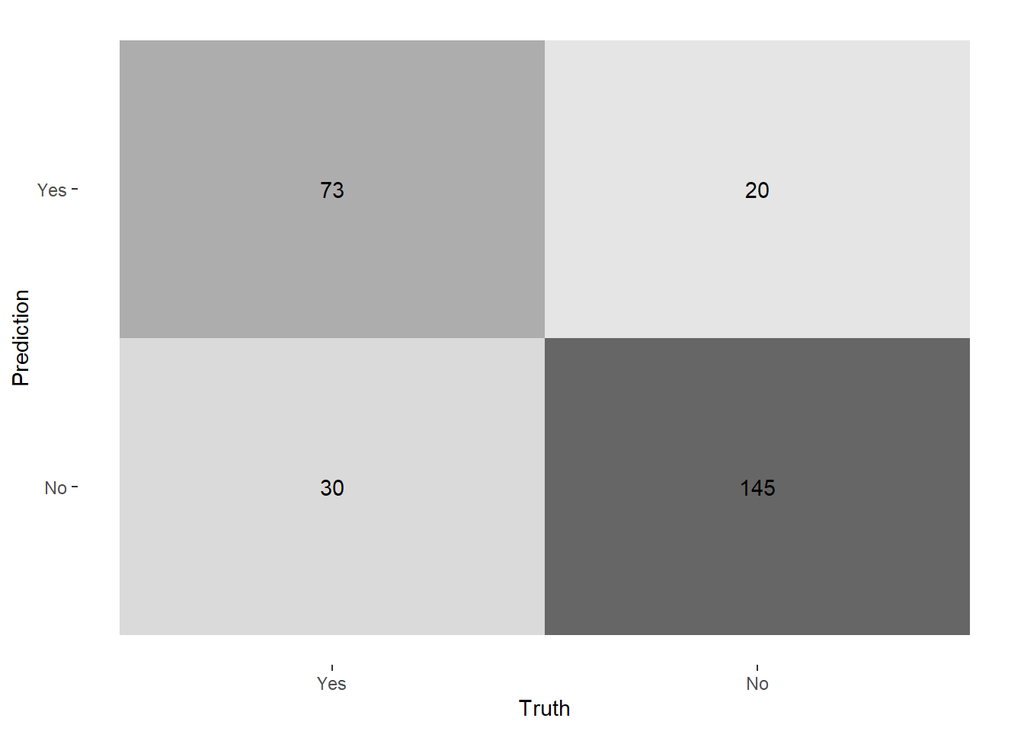

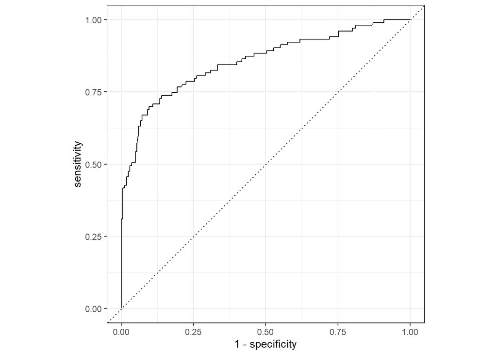

From the confusion matrix we can observe that there was a much larger number of predictions that were the same as the real values than there were predictions that were not the same. We had about a 70% accuracy for the yes predictions and about an 88% accuracy for the no predictions.

```
## # A tibble: 1 x 3
##   .metric .estimator .estimate
##   <chr>   <chr>          <dbl>
## 1 roc_auc binary         0.855
```

Overall, the model performed well. The testing and training accuracy were almost the same, which is to be expected because we stratified the data to get even distributions of those who survived and those who didn’t. Thus, the model should perform similarly on both sets of data. From the AUC value we can also observe that the model did will, with a 85% change that the model will distinguish between a yes and no class.